# Introduction to ggplot2

# Introduction

[ggplot2](https://ggplot2.tidyverse.org/) is an R implementation of the *Grammar of Graphics*. The idea is to define the basic “words” from which visualizations are built, and then let users compose them in original ways. This is in contrast to systems with prespecified chart types, where the user is forced to pick from a limited dropdown menu of plots. Just like in ordinary language, the creative combination of simple building blocks can support a very wide range of expression.

These are libraries we’ll use in this lecture.

```r
library(tidyverse)
library(dslabs)
library(ggrepel)
library(scales)
```

# Iterative Visualization

We’re going to create this plot in these notes.

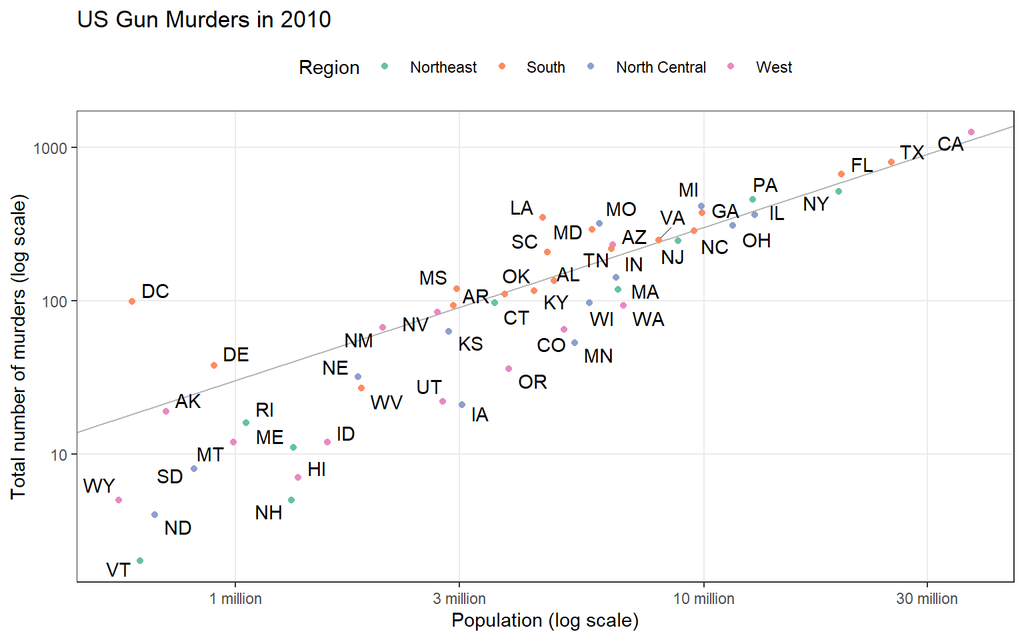

Every ggplot2 plot is made from three components,

- Data: This is the `data.frame` that we want to visualize.
- Geometry: These are the types of visual marks that appear on the plot.
- Aesthetic Mapping: This links the data with the visual marks.

# The Data

Let’s load up the data. Each row is an observation, and each column is an attribute that describes something about that observation. This is important because each mark that you see on a ggplot – a line, a point, a tile, … – had to start out as a row within an R `data.frame` (with the exception of some one-variable plots like boxplots) The visual properties of the mark (e.g., color) are determined by the values along columns.

Here’s an example of the data above in tidy format,

```r
data(murders)
head(murders)
```

```
##        state abb region population total
## 1    Alabama  AL  South    4779736   135
## 2     Alaska  AK   West     710231    19
## 3    Arizona  AZ   West    6392017   232
## 4   Arkansas  AR  South    2915918    93
## 5 California  CA   West   37253956  1257
## 6   Colorado  CO   West    5029196    65
```

This is one example of how the same information might be stored in a non-tidy way, making visualization much harder.

```r
non_tidy <- data.frame(t(murders))
colnames(non_tidy) <- non_tidy[1, ]
non_tidy <- non_tidy[-1, ]
non_tidy[, 1:6]
```

```
##             Alabama   Alaska  Arizona Arkansas California Colorado
## abb              AL       AK       AZ       AR         CA       CO
## region        South     West     West    South       West     West
## population  4779736   710231  6392017  2915918   37253956  5029196
## total           135       19      232       93       1257       65
```

Often, one of the hardest parts in making a ggplot2 plot is not coming up with the right ggplot2 commands, but reshaping the data so that it’s in a tidy format.

# Geometries

The words in the grammar of graphics are the geometry layers. We can associate each row of a data frame with points, lines, tiles, etc., just by referring to the appropriate geom in ggplot2. A typical plot will compose a chain of layers on top of a dataset,

> ggplot(data) + [layer 1] + [layer 2] + …

For example, by deconstructing the plot above, we would expect to have point and text layers. For now, let’s just tell the plot to put all the `geom`’s at the origin.

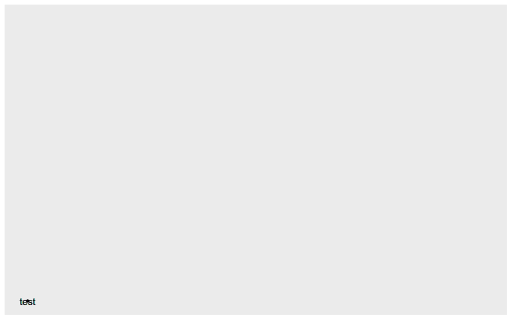

```r
ggplot(murders) +
  geom_point(x = 0, y = 0) +
  geom_text(x = 0, y = 0, label = "test")
```

You can see all the types of `geoms` in the [cheat sheet](https://github.com/rstudio/cheatsheets/blob/master/data-visualization-2.1.pdf).

# Aesthetic Mappings

Aesthetic mappings make the connection between the data and the geometry. It’s the piece that translates abstract data fields into visual properties. Analyzing the original graph, we recognize these specific mappings,

- State Population; $x$-axis coordinate
- Number of murders; $y$-axis coordinate
- Geographical region; color

To establish these mappings, we need to use the `aes` function. Notice that column names don’t have to be quoted, or preceded with `murders$` – ggplot2 knows to refer back to the data frame we specified in the original `ggplot` call, which was `murders`.

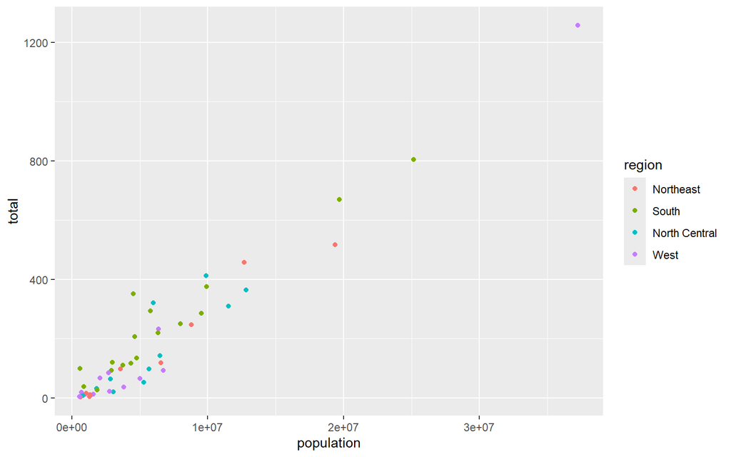

```r
ggplot(murders) +
  geom_point(aes(x = population, y = total, col = region))
```

The original plot used a log-scale. To transform the x and y axes, we can use scales.

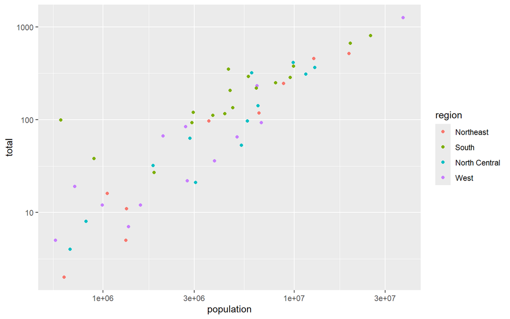

```r
ggplot(murders) +
  geom_point(aes(x = population, y = total, col = region)) +
  scale_x_log10() +
  scale_y_log10()
```

One nuance is that scales aren’t limited to $x$ and $y$ transformations. They can be applied to modify any relationship between a data field and its appearance on the page. For example, this changes the mapping between the region field and circle color.

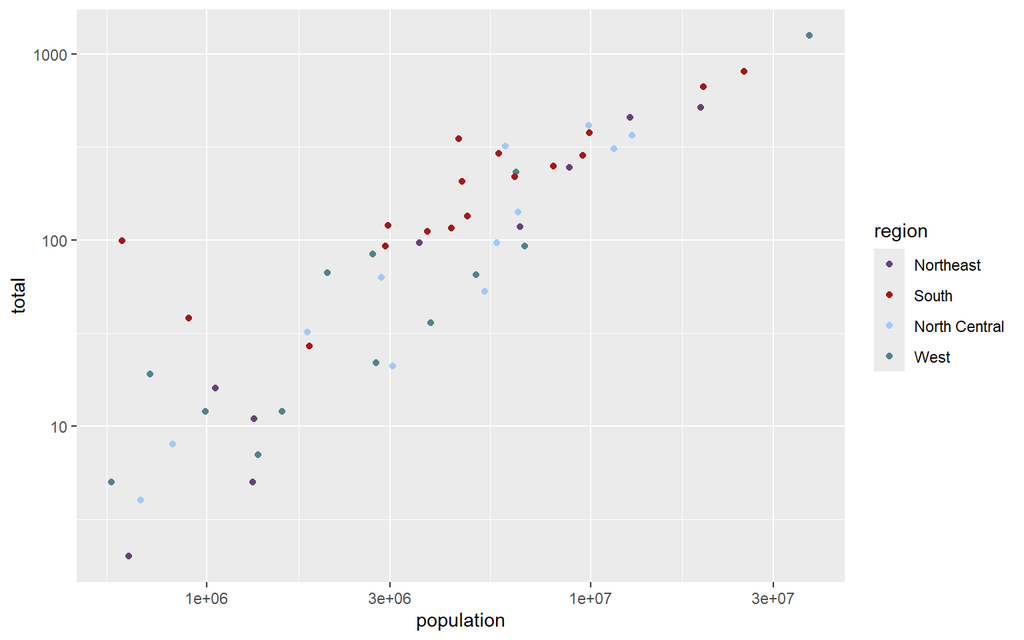

```r
ggplot(murders) +
  geom_point(aes(x = population, y = total, col = region)) +
  scale_x_log10() +
  scale_y_log10() +
  scale_color_manual(values = c("#6a4078", "#aa1518", "#9ecaf8", "#50838c"))
```

A problem with this graph is that it doesn’t tell us which state each point corresponds to. For that, we’ll need text labels. We can encode the coordinates for these marks again using `aes`, but this time within a `geom_text` layer.

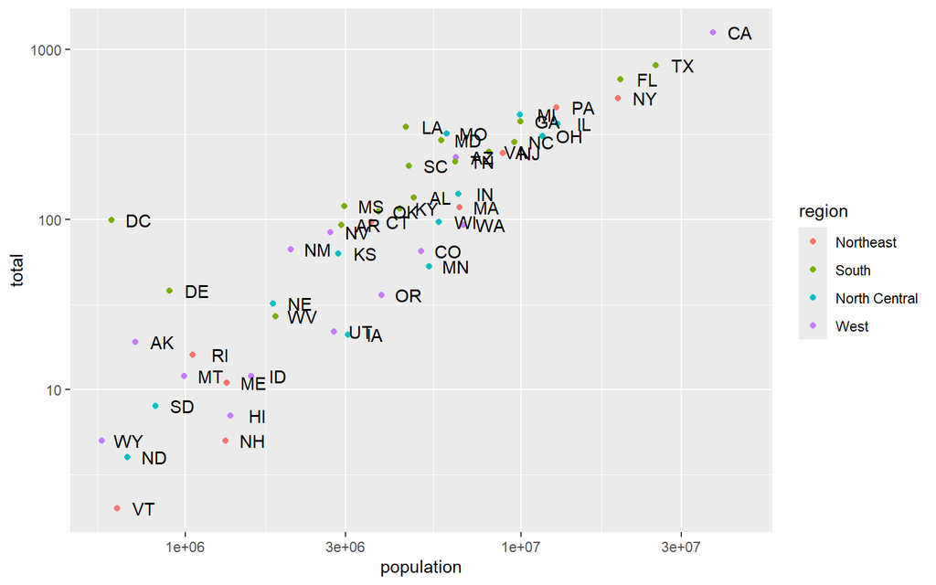

```r
ggplot(murders) +
  geom_point(aes(x = population, y = total, col = region)) +
  geom_text(
    aes(x = population, y = total, label = abb),
    nudge_x = 0.08 # what would happen if I remove this?
  ) +
  scale_x_log10() +
  scale_y_log10()
```

Note that each type of layer uses different visual properties to encode the data – the argument `label` is only available for the `geom_text` layer. You can see which aesthetic mappings are required for each type of `geom` by checking that `geom`’s documentation page, under the Aesthetics heading.

It’s usually a good thing to make your code as concise as possible. For ggplot2, we can achieve this by sharing elements across `aes` calls (e.g., not having to type `population` and `total` twice). This can be done by defining a “global” aesthetic, putting it inside the initial `ggplot` call.

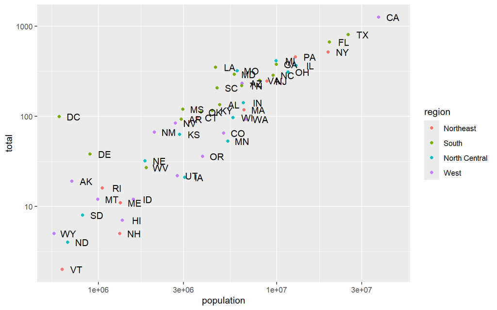

```r
ggplot(murders, aes(x = population, y = total)) +
  geom_point(aes(col = region)) +
  geom_text(aes(label = abb), nudge_x = 0.08) +
  scale_x_log10() +
  scale_y_log10()
```

# Finishing Touches

How can we improve the readability of this plot? You might already have ideas,

1. Prevent labels from overlapping. It’s impossible to read some of the state names.
2. Add a line showing the national rate. This serves as a point of reference, allowing us to see whether an individual state is above or below the national murder rate.
3. Give meaningful axis / legend labels and a title.
4. Move the legend to the top of the figure. Right now, we’re wasting a lot of visual real estate in the right hand side, just to let people know what each color means.
5. Use a better color theme.

For 1., the `ggrepel` package offers a function `geom_text_repel` which finds better positions for the labels, drawing links when necessary.

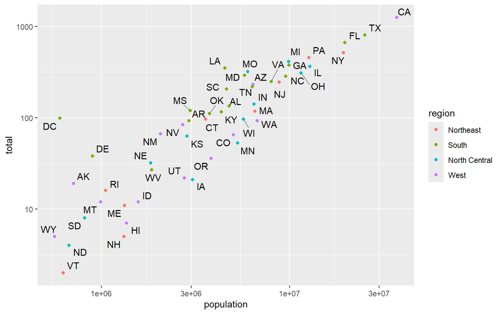

```r
ggplot(murders, aes(x = population, y = total)) +
  geom_text_repel(aes(label = abb), segment.size = 0.2) + # Moved this layer here so the points are on top of the connecting segments
  geom_point(aes(col = region)) +
  scale_x_log10() +
  scale_y_log10()
```

For 2., let’s first compute the national murder rate,

```r
r <- murders %>%
  summarize(rate = sum(total) /  sum(population)) %>%
  pull(rate)
r
```

```
## [1] 3.034555e-05
```

Now, we can use this as the intercept in a `geom_abline` layer, which encodes a slope (which defaults to 1) and intercept as a line on a graph.

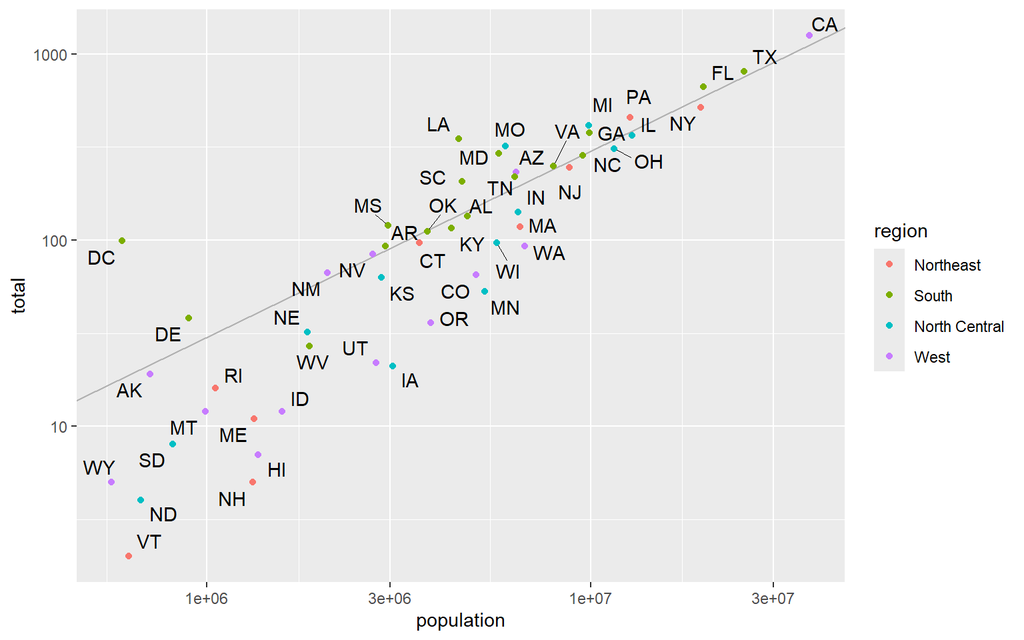

```r
ggplot(murders, aes(x = population, y = total)) +
  geom_abline(intercept = log10(r), linewidth = 0.4, col = "#b3b3b3") +
  geom_text_repel(aes(label = abb), segment.size = 0.2) +
  geom_point(aes(col = region)) +
  scale_x_log10() +
  scale_y_log10()
```

For 3., we can add a `labs` layer to write labels and a `theme` to reposition the legend. I used `unit_format` from the `scales` package to change the scientific notation in the $x$-axis labels to something more readable.

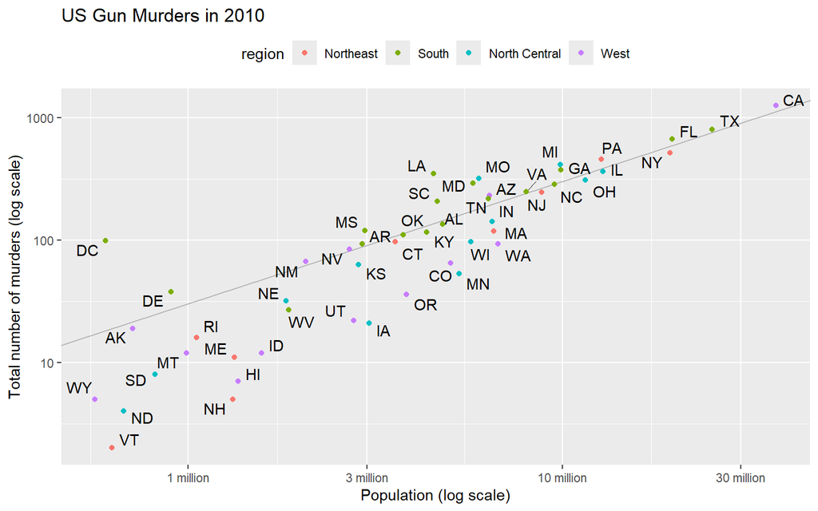

```r
ggplot(murders, aes(x = population, y = total)) +
  geom_abline(intercept = log10(r), linewidth = 0.4, col = "#b3b3b3") +
  geom_text_repel(aes(label = abb), segment.size = 0.2) +
  geom_point(aes(col = region)) +
  scale_x_log10(labels = unit_format(unit = "million", scale = 1e-6)) + # used to convert scientific notation to readable labels
  scale_y_log10() +
  labs(
    x = "Population (log scale)",
    y = "Total number of murders (log scale)",
    color = "region",
    title = "US Gun Murders in 2010"
  ) +
  theme(legend.position = "top")
```

For 5., I find the gray background with reference lines a bit distracting. We can simplify the appearance using `theme_bw`. I also like the colorbrewer palette, which can be used by calling a different color scale.

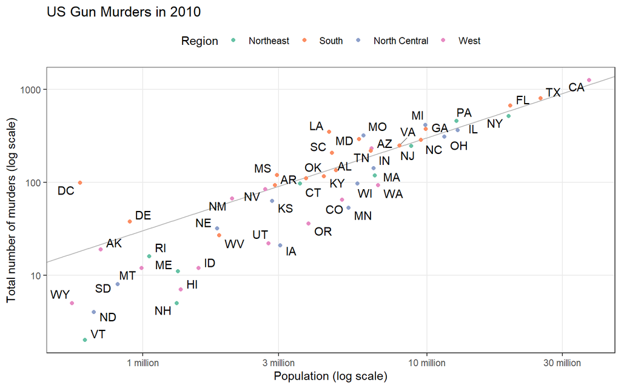

```r
ggplot(murders, aes(x = population, y = total)) +
  geom_abline(intercept = log10(r), linewidth = 0.4, col = "#b3b3b3") +
  geom_text_repel(aes(label = abb), segment.size = 0.2) +
  geom_point(aes(col = region)) +
  scale_x_log10(labels = unit_format(unit = "million", scale = 1e-6)) +
  scale_y_log10() +
  scale_color_brewer(palette = "Set2") +
  labs(
    x = "Population (log scale)",
    y = "Total number of murders (log scale)",
    color = "Region",
    title = "US Gun Murders in 2010"
  ) +
  theme_bw() +
  theme(
    legend.position = "top",
    panel.grid.minor = element_blank()
  )
```

# Beyond Finishing Touches

Almost anything can be customized in a ggplot; there is far too much for us to A) list every possible way things can be customized or B) expect you to know them all, even if we could list them.

While you visualize, we highly encourage you to explore ggplot customization on your own. Learning how to Google and StackOverflow tiny ggplot tweaks is a huge part of visualization that won’t show up in any course learning outcome. Thoughts like “how do I get rid of the gray background around the points in the legend?” or “how do I move the X axis title a little further away from the plot?” or “how do I get rid of the minor gridlines between the major ones?” are perfect candidates for things you can learn with a quick search.

In that spirit, here are some not-straightforward bonus exercises for the curious. These encourage you to look at your graphics more carefully and start your mental collection of customizations!

- Re-order the order of regions in the legend. Hint: Reset the factor levels in the `region` field of the `murders` data.frame.
- Only show labels for a subset of states that are far from the national rate. Hint: Filter the `murders` data.frame, and use a `data` field specific to the `geom_text_repel` layer.
- Move “Population (log scale)” a little further down, away from the plot.
- Increase the size of the circles in the legend, but not in the plot. Hint: Use `override.aes` within a `guide`.

See the R Markdown file on the course GitHub for solutions!

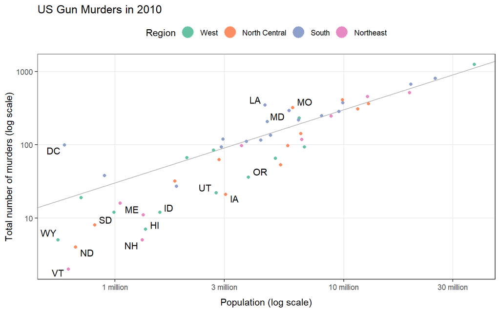